# Assignment 2 Quant

Ryan Johnson

9/16/2020

### Description

```r
hh_data <- read_csv("travisHH.csv")
attach(hh_data)
```

- The dataset loaded above includes four continuous variables - household income (HINCP), monthly rent (RNTP), number of people per household (NP), and number of bedrooms per household (BDSP) - and two categorical variables - household type (HHT_label), and the decade of building construction (BLDG_AGE_dec). These household-level variables are taken from the 2018 ACS 1-year sample, in the area of Travis County, TX.
- This data was modified from my original data set, as I found that including households with either rental or mortgage payments cause too many entries with zero values in each of those variables. I added the bedrooms-per-household variable to better investigate relationships between household size and type, and rental costs. This change was accomplished by removing the mortgage payment variable, adding the bedrooms variable, and adjusting my filter function accordingly.
- As an aside, Sage V. showed me how to incorporate a floating Table of Contents, which I have done on this page.

### Household income (dollars) - continuous

- Sample characteristics:

```r
paste("The sample mean household income is",
      prettyNum(mean(HINCP), digits = 5), "dollars.")
```

```
## [1] "The sample mean household income is 79469 dollars."
```

```r
paste("The sample median household income is",
      prettyNum(median(HINCP), digits = 5), "dollars.")
```

```
## [1] "The sample median household income is 60000 dollars."
```

```r
paste("The sample standard deviation for household income is",
      prettyNum(sd(HINCP), digits = 5), "dollars.")
```

```
## [1] "The sample standard deviation for household income is 81748 dollars."
```

```r
paste("The sample interquartile range for household income is",
      quantile(HINCP)["25%"], "to", quantile(HINCP)["75%"], "dollars.")
```

```
## [1] "The sample interquartile range for household income is 31800 to 101060 dollars."
```

```r
paste("The 95-percent confidence interval for the population mean is",
      prettyNum(pop_mean$conf.int[1], digits = 5), "to",
      prettyNum(pop_mean$conf.int[2], digits = 5), "dollars.")
```

```
## [1] "The 95-percent confidence interval for the population mean is 76868 to 82070 dollars."
```

- Figure 1. Histogram of distribution of sample household income:

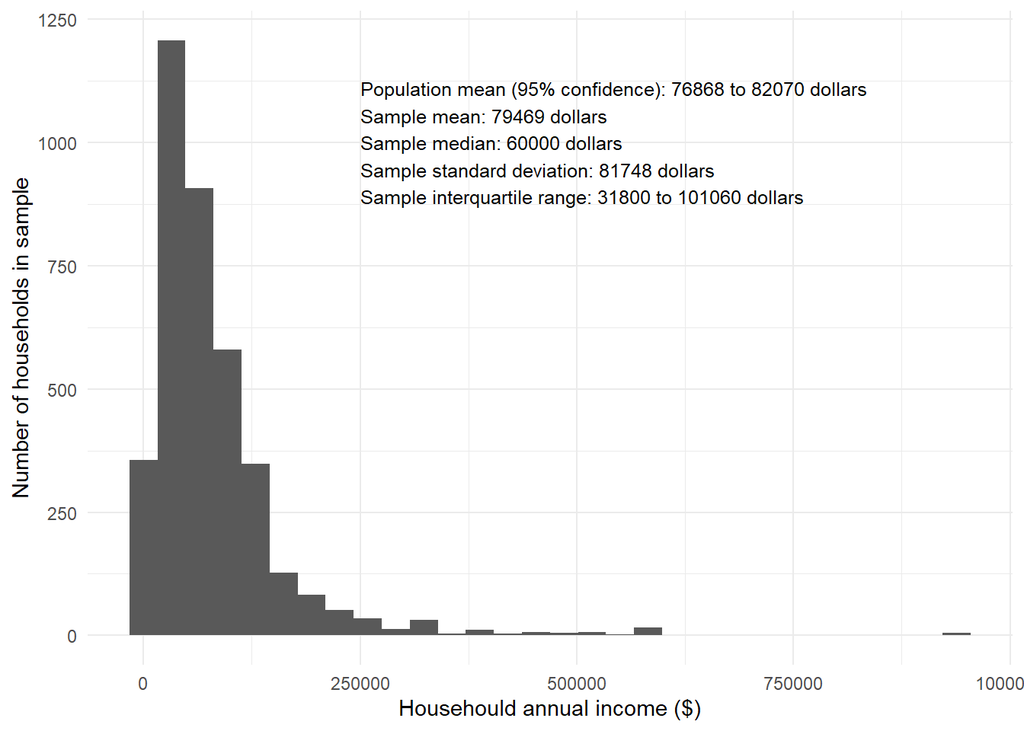

```r
HINCP_hist <- ggplot(hh_data, aes(x = HINCP)) +
  geom_histogram()

HINCP_hist +
  theme_minimal() +
  scale_x_continuous(name = "Househould annual income ($)") +
  scale_y_continuous(name = "Number of households in sample") +
  annotate("text", x = 250000, y = 1125, size = 3.25,
           label = paste("Population mean (95% confidence):",
                         prettyNum(pop_mean$conf.int[1], digits = 5), "to",
                         prettyNum(pop_mean$conf.int[2], digits = 5), "dollars",
                         "\nSample mean:",
                         prettyNum(mean(HINCP), digits = 5), "dollars",
                         "\nSample median:",
                         prettyNum(median(HINCP), digits = 5), "dollars",
                         "\nSample standard deviation:",
                         prettyNum(sd(HINCP), digits = 5), "dollars",
                         "\nSample interquartile range:",
                         prettyNum(quantile(HINCP)["25%"], digits = 5),
                         "to",
                         prettyNum(quantile(HINCP)["75%"], digits = 5),
                         "dollars"),
           hjust = 0, vjust = 1)
```

- As clearly seen in the histogram above, household income in this sample population is not distributed normally, but instead has a right skew, more like a negative binomial distribution. A few extreme outliers can be seen in the $1,000,000 range, which makes sense given this sample’s location in Austin, a booming tech hub. The impact of these outliers is clear in that the median value is significantly lower than the mean.

### Monthly rent payment (dollars) - continuous

- Sample characteristics:

```r
paste("The sample mean monthly rent is",
      prettyNum(mean(RNTP), digits = 4), "dollars.")
```

```
## [1] "The sample mean monthly rent is 1296 dollars."
```

```r
paste("The sample median monthly rent is",
      prettyNum(median(RNTP), digits = 4), "dollars.")
```

```
## [1] "The sample median monthly rent is 1200 dollars."
```

```r
paste("The sample standard deviation for monthly rent is",
      prettyNum(sd(RNTP), digits = 3), "dollars.")
```

```
## [1] "The sample standard deviation for monthly rent is 533 dollars."
```

```r
paste("The sample interquartile range for monthly rent is",
      quantile(RNTP)["25%"], "to", quantile(RNTP)["75%"], "dollars.")
```

```
## [1] "The sample interquartile range for monthly rent is 940 to 1600 dollars."
```

```r
paste("The 95-percent confidence interval for the population mean is",
      prettyNum(rntp_mean$conf.int[1], digits = 4), "to",
      prettyNum(rntp_mean$conf.int[2], digits = 4), "dollars.")
```

```
## [1] "The 95-percent confidence interval for the population mean is 1279 to 1313 dollars."
```

- Figure 2. Overall distribution of rents in this sample:

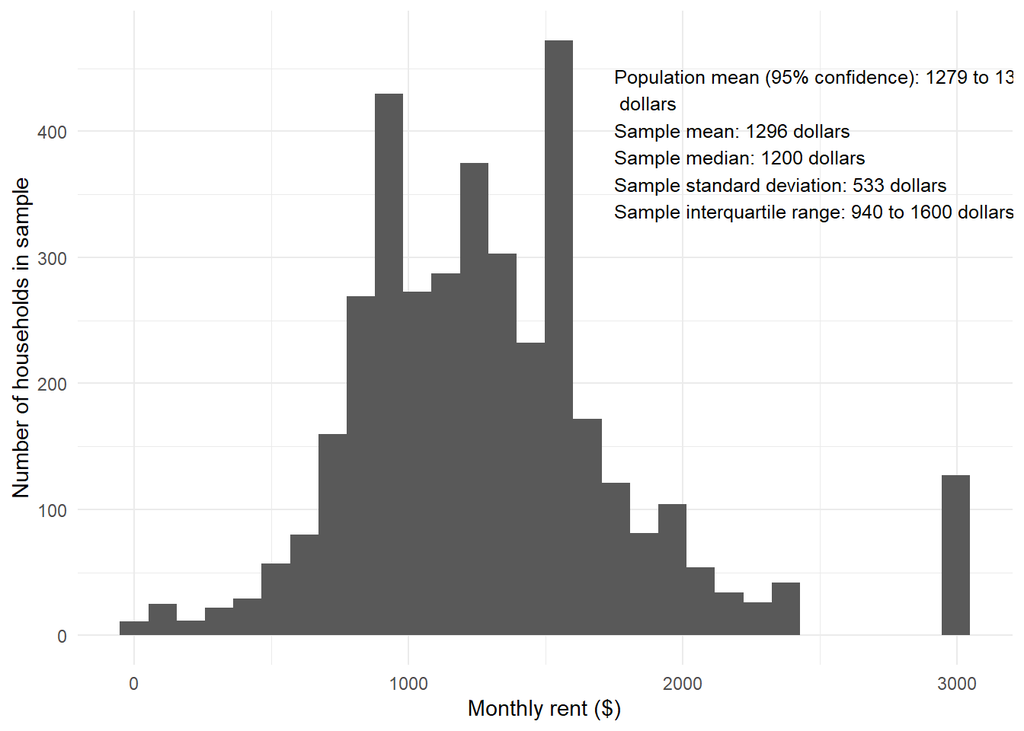

```r
RNTP_hist <- ggplot(hh_data, aes(x = RNTP)) +
  geom_histogram()

RNTP_hist +
  theme_minimal() +
  scale_x_continuous(name = "Monthly rent ($)") +
  scale_y_continuous(name = "Number of households in sample") +
  annotate("text", x = 1750, y = 450, size = 3.25,
           label = paste("Population mean (95% confidence):",
                         prettyNum(rntp_mean$conf.int[1], digits = 4), "to",
                         prettyNum(rntp_mean$conf.int[2], digits = 4), "\n dollars",
                         "\nSample mean:",
                         prettyNum(mean(RNTP), digits = 4), "dollars",
                         "\nSample median:",
                         prettyNum(median(RNTP), digits = 4), "dollars",
                         "\nSample standard deviation:",
                         prettyNum(sd(RNTP), digits = 3), "dollars",
                         "\nSample interquartile range:",
                         prettyNum(quantile(RNTP)["25%"], digits = 4),
                         "to",
                         prettyNum(quantile(RNTP)["75%"], digits = 4),
                         "dollars"),
           hjust = 0, vjust = 1)
```

- The distribution of monthly rents in this sample is closer to normal, albeit with a significant number of outliers at $3,000/month. This represents one potential limitation of the data, as it is unclear whether this was the actual maximum value recorded, or simply the upper limit of potential values. There are also discernible peaks at approximately 900 and 1600, lined up with the 1st and 3rd quartiles.

### Number of people per household - continuous

- Sample characteristics:

```r
paste("The sample mean household size is",
      prettyNum(mean(NP), digits = 1), "people.")
```

```
## [1] "The sample mean household size is 3 people."
```

```r
paste("The sample median household size is",
      prettyNum(median(NP), digits = 1), "people.")
```

```
## [1] "The sample median household size is 2 people."
```

```r
paste("The sample standard deviation for household size is",
      prettyNum(sd(NP), digits = 1), "people.")
```

```
## [1] "The sample standard deviation for household size is 2 people."
```

```r
paste("The sample interquartile range for household size is",
      quantile(NP)["25%"], "to", quantile(NP)["75%"], "people.")
```

```
## [1] "The sample interquartile range for household size is 2 to 4 people."
```

```r
paste("The 95-percent confidence interval for the population mean is",
      prettyNum(np_mean$conf.int[1], digits = 1), "to",
      prettyNum(np_mean$conf.int[2], digits = 1), "people.")
```

```
## [1] "The 95-percent confidence interval for the population mean is 3 to 3 people."
```

- Figure 3. Overall distribution of household size in this sample:

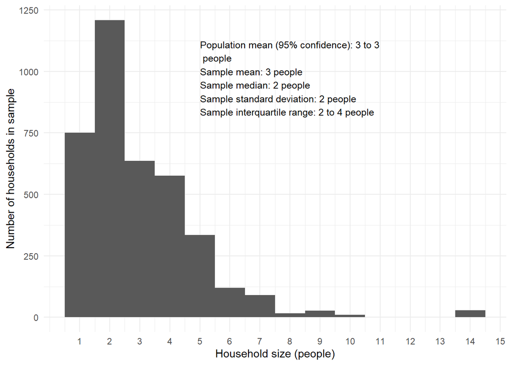

```r
NP_hist <- ggplot(hh_data, aes(x = NP)) +
  geom_histogram(binwidth = 1)

NP_hist +
  theme_minimal() +
  scale_x_continuous(name = "Household size (people)",
                     breaks = seq(1, 15, by = 1)) +
  scale_y_continuous(name = "Number of households in sample") +
  annotate("text", x = 5, y = 1125, size = 3.25,
           label = paste("Population mean (95% confidence):",
                         prettyNum(np_mean$conf.int[1], digits = 1), "to",
                         prettyNum(np_mean$conf.int[2], digits = 1), "\n people",
                         "\nSample mean:",
                         prettyNum(mean(NP), digits = 1), "people",
                         "\nSample median:",
                         prettyNum(median(NP), digits = 1), "people",
                         "\nSample standard deviation:",
                         prettyNum(sd(NP), digits = 1), "people",
                         "\nSample interquartile range:",
                         prettyNum(quantile(NP)["25%"], digits = 1),
                         "to",
                         prettyNum(quantile(NP)["75%"], digits = 1),
                         "people"),
           hjust = 0, vjust = 1)
```

- The distribution of household size in this sample appears to be a Poisson distribution, or negative binomial. Because this value only represents whole people, the histogram is very clearly binned into whole integers. As with the other non-normal variables, a smaller number of outliers can be seen at the extreme high value. These are likely rental households occupied by groups of students, or very large families.

### Number of bedrooms per household - continuous

- Sample characteristics:

```r
paste("The sample mean bedrooms per household is",
      prettyNum(mean(BDSP), digits = 2), "bedrooms.")
```

```
## [1] "The sample mean bedrooms per household is 2.1 bedrooms."
```

```r
paste("The sample median bedrooms per household is",
      prettyNum(median(BDSP), digits = 2), "bedrooms.")
```

```
## [1] "The sample median bedrooms per household is 2 bedrooms."
```

```r
paste("The sample standard deviation for bedrooms per household is",
      prettyNum(sd(BDSP), digits = 2), "bedrooms.")
```

```
## [1] "The sample standard deviation for bedrooms per household is 1 bedrooms."
```

```r
paste("The sample interquartile range for bedrooms per household is",
      quantile(BDSP)["25%"], "to", quantile(BDSP)["75%"], "bedrooms.")
```

```
## [1] "The sample interquartile range for bedrooms per household is 1 to 3 bedrooms."
```

```r
paste("The 95-percent confidence interval for the population mean is",
      prettyNum(bdsp_mean$conf.int[1], digits = 2), "to",
      prettyNum(bdsp_mean$conf.int[2], digits = 2), "bedrooms.")
```

```
## [1] "The 95-percent confidence interval for the population mean is 2.1 to 2.1 bedrooms."
```

- Figure 4. Overall distribution of bedrooms per household in this sample

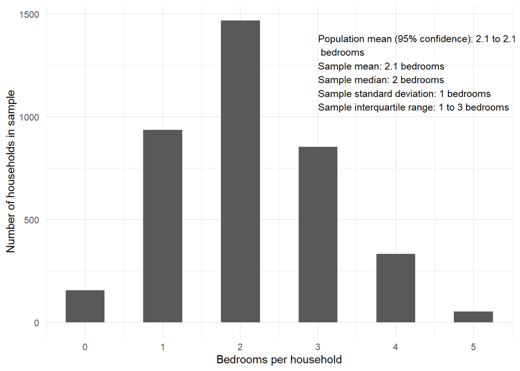

```r
BDSP_hist <- ggplot(hh_data, aes(x = BDSP)) +
  geom_histogram(binwidth = .5)

BDSP_hist +
  theme_minimal() +
  scale_x_continuous(name = "Bedrooms per household",
                     breaks = seq(0, 6, by = 1)) +
  scale_y_continuous(name = "Number of households in sample") +
  annotate("text", x = 3, y = 1400, size = 3.25,
           label = paste("Population mean (95% confidence):",
                         prettyNum(bdsp_mean$conf.int[1], digits = 2), "to",
                         prettyNum(bdsp_mean$conf.int[2], digits = 2), "\n bedrooms",
                         "\nSample mean:",
                         prettyNum(mean(BDSP), digits = 2), "bedrooms",
                         "\nSample median:",
                         prettyNum(median(BDSP), digits = 2), "bedrooms",
                         "\nSample standard deviation:",
                         prettyNum(sd(BDSP), digits = 2), "bedrooms",
                         "\nSample interquartile range:",
                         prettyNum(quantile(BDSP)["25%"], digits = 2),
                         "to",
                         prettyNum(quantile(BDSP)["75%"], digits = 2),
                         "bedrooms"),
           hjust = 0, vjust = 1)
```

- The distribution of bedroom counts in this sample is also close to normal. As with number of people, this data is only collected in whole numbers, resulting in the spacious, binned distribution. This data appears to have a slight right skew, but it is hard to say definitively.

### Household type - categorical

```r
types <- unique(hh_data$HHT_label)
types
```

```r
fam_single_female <- t.test(HHT_label == types[1])
multi_male <- t.test(HHT_label == types[2])
single_female <- t.test(HHT_label == types[3])
married <- t.test(HHT_label == types[4])
single_male <- t.test(HHT_label == types[5])
fam_single_male <- t.test(HHT_label == types[6])
multi_female <- t.test(HHT_label == types[7])

shares <- tibble(Type = c("Single parent household - female",
                            "Non-family household - male",
                            "Single female household",
                            "Married couple household",
                            "Single male household",
                            "Single parent household - male",
                            "Non-family household - female"),
                 `Share` = c(fam_single_female$estimate,
                             multi_male$estimate,
                             single_female$estimate,
                             married$estimate,
                             single_male$estimate,
                             fam_single_male$estimate,
                             multi_female$estimate),
                 Low = c(fam_single_female$conf.int[1],
                         multi_male$conf.int[1],
                         single_female$conf.int[1],
                         married$conf.int[1],
                         single_male$conf.int[1],
                         fam_single_male$conf.int[1],
                         multi_female$conf.int[1]),
                 High = c(fam_single_female$conf.int[2],
                         multi_male$conf.int[2],
                         single_female$conf.int[2],
                         married$conf.int[2],
                         single_male$conf.int[2],
                         fam_single_male$conf.int[2],
                         multi_female$conf.int[2]))
knitr::kable(shares, caption = "Table 1. Proportions and 95-percent confidence intervals")
```

[output not shown]

- Figure 5. Percent share of sample by household types

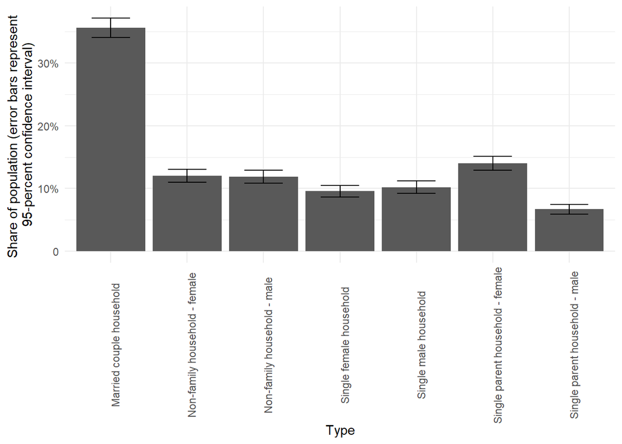

```r
ggplot(shares, aes(x = Type, y = Share, ymin = Low, ymax = High)) +
  geom_bar(stat = "identity") +
  geom_errorbar(width = .5) +
  theme_minimal() +
  theme(axis.text.x = element_text(angle = 90)) +
  scale_y_continuous(name = "Share of population (error bars represent \n95-percent confidence interval)",
                     breaks = seq(0, 0.5, by = .1),
                     labels = c("0", "10%", "20%", "30%", "40%", "50%"))
```

- The largest category of households in this sample is, by far, married couple-headed households. The second-largest category is single-parent families headed by a female householder, which represents twice as great a share compared to male-headed single-parent households.

### Decade of construction - categorical

```r
ages <- unique(hh_data$BLDG_AGE_dec)
ages
```

```r
twotens <- t.test(BLDG_AGE_dec == "2010s")
twos <- t.test(BLDG_AGE_dec == "2000s")
nines <- t.test(BLDG_AGE_dec == "1990s")
eights <- t.test(BLDG_AGE_dec == "1980s")
sevens <- t.test(BLDG_AGE_dec == "1970s")
sixes <- t.test(BLDG_AGE_dec == "1960s")
fives <- t.test(BLDG_AGE_dec == "1950s")
fours <- t.test(BLDG_AGE_dec == "1940s")
threes <- t.test(BLDG_AGE_dec == "pre-1940s")

bldgshares <- tibble(Decade = c("2010s",
                            "2000s",
                            "1990s",
                            "1980s",
                            "1970s",
                            "1960s",
                            "1950s",
                            "1940s",
                            "pre-1940s"),
                 `Share` = c(twotens$estimate,
                             twos$estimate,
                             nines$estimate,
                             eights$estimate,
                             sevens$estimate,
                             sixes$estimate,
                             fives$estimate,
                             fours$estimate,
                             threes$estimate),
                 Low = c(twotens$conf.int[1],
                         twos$conf.int[1],
                         nines$conf.int[1],
                         eights$conf.int[1],
                         sevens$conf.int[1],
                         sixes$conf.int[1],
                         fives$conf.int[1],
                         fours$conf.int[1],
                         threes$conf.int[1]),
                 High = c(twotens$conf.int[2],
                         twos$conf.int[2],
                         nines$conf.int[2],
                         eights$conf.int[2],
                         sevens$conf.int[2],
                         sixes$conf.int[2],
                         fives$conf.int[2],
                         fours$conf.int[2],
                         threes$conf.int[2]))
knitr::kable(shares, caption = "Table 2. Proportions and 95-percent confidence intervals")
```

[output not shown]

- Figure 6. Percent share of sample by building age

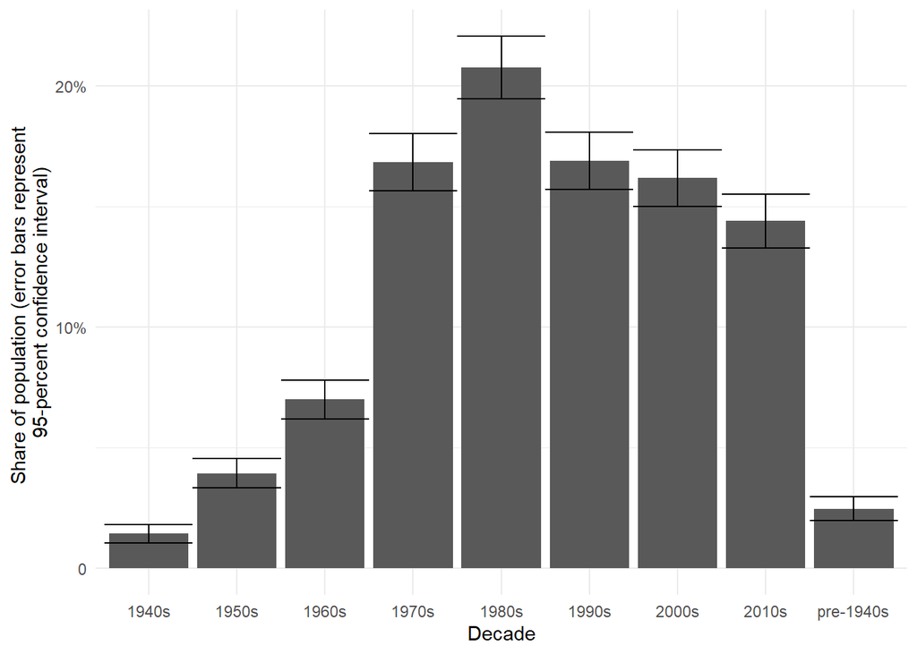

```r
ggplot(bldgshares, aes(x = Decade, y = Share, ymin = Low, ymax = High)) +
  geom_bar(stat = "identity") +
  geom_errorbar(width = 1) +
  theme_minimal() +
  scale_y_continuous(name = "Share of population (error bars represent \n95-percent confidence interval)",
                     breaks = seq(0, 0.5, by = .1),
                     labels = c("0", "10%", "20%", "30%", "40%", "50%"))
```

- We see that the majority of existing structures were built from 1970 and later, with the 1980s being the single most common decade of construction. The 1940s represent the lowest-represented decade, likely due to the demand and supply shortages caused by WOrld War II.